# Getting Started

This vignette showcases the different sampling designs applied to the same species.

## set up

`safeHavens` can be installed directly from github.

```r
# remotes::install_github('sagesteppe/safeHavens')
```

```r
library(safeHavens)
library(sf) ## vector operations
library(terra) ## raster operations
library(spData) ## basemap data
library(dplyr) ## general data handling
library(ggplot2) ## plotting
library(patchwork) ## multiplots
set.seed(23)

planar_proj <- "+proj=laea +lat_0=-15 +lon_0=-60 +x_0=0 +y_0=0 +datum=WGS84 +units=m +no_defs"
```

## Defining a Species Range or Domain for Sampling

The core of `safeHavens` sampling schemes is the species range or domain. Curators can sample across the entire range or focus on a region, such as a country or ecoregion. Both approaches are supported. We show how to use occurrence data to define species ranges across various sampling schemes.

Below we will use `sf` to simply buffer occurrence points to create a species range across multiple South American nations.

[figure not shown]

```r
x <- read.csv(file.path(system.file(package="dismo"), 'ex', 'bradypus.csv'))
x <- x[,c('lon', 'lat')]
x <- sf::st_as_sf(x, coords = c('lon', 'lat'), crs = 4326)
x_buff <- sf::st_transform(x, planar_proj) |>
  # we are working in planar metric coordinates, we are
  # buffer by this many / 1000 kilometers.
  sf::st_buffer(125000) |>
  sf::st_as_sfc() |>
  sf::st_union()

plot(x_buff)
```

Alternatives include creating a convex hull for widespread species (see ‘Worked Example’) or masking a binary SDM surface as the domain (see below and ‘Species Distribution Model’).

# Prep a base map

We will use the `spData` package which uses [naturalearth](https://www.naturalearthdata.com/) for it’s `world` data and is suitable for creating maps at a variety of resolutions.

```r
x_extra_buff <- sf::st_buffer(x_buff, 100000) |> # add a buffer to 'frame' the maps
  sf::st_transform(4326)

americas <- spData::world
americas <- sf::st_crop(americas, sf::st_bbox(x_extra_buff)) |>
  dplyr::select(name_long)
Warning: attribute variables are assumed to be spatially constant throughout
all geometries

bb <- sf::st_bbox(x_extra_buff)

map <- ggplot() +
  geom_sf(data = americas) +
  theme(
    legend.position = 'none',
    panel.background = element_rect(fill = "aliceblue"),
    panel.grid.minor.x = element_line(colour = "red", linetype = 3, linewidth  = 0.5),
    axis.ticks=element_blank(),
    axis.text=element_blank(),
    plot.background=element_rect(colour="steelblue"),
    plot.margin=grid::unit(c(0,0,0,0),"cm"),
    axis.ticks.length = unit(0, "pt"))+
  coord_sf(xlim = c(bb[1], bb[3]), ylim = c(bb[2], bb[4]), expand = FALSE)

rm(x_extra_buff, americas)
```

# Running the Various Sample Design Algorithms

Now that we have some data which can represent species ranges, we can run the various sampling approaches. The table in the introduction is reproduced here.

| Function | Description | Comp. | Envi. |
| --- | --- | --- | --- |
| `PointBasedSample` | Creates points to make pieces over area | L | L |
| `EqualAreaSample` | Breaks area into similar size pieces | L | L |
| `OpportunisticSample` | Using PBS with existing records | L | L |
| `KMedoidsBasedSample` | Use ecoregions or STSz for sample | L | M |
| `IBDBasedSample` | Breaks species range into clusters | H | M |
| `PolygonBasedSample` | Using existing ecoregions to sample | L | H |
| `EnvironmentalBasedSample` | Uses correlations from SDM to sample | H | H |

*Note in this table ‘Comp.’ and ‘Envi.’ refer to computational and environmental complexity respectively, and range from low (L) through medium to high.*

## PointBasedSample

`PointBasedSample` selects a set of regularly spaced points across the domain and assigns each point’s cluster to the area nearest to it. This strictly spatial approach relies on even spacing as its main differentiator. It will work very well for common species without many gaps in their distributions.

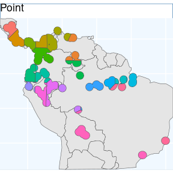

```r
pbs <- PointBasedSample(x_buff, reps = 50, BS.reps = 333)
pbs.sf <- pbs[['Geometry']]

pbs.p <- map +
  geom_sf(data = pbs.sf, aes(fill = factor(ID))) +
#  geom_sf_label(data = pbs.sf, aes(label = ID), alpha = 0.4) +
  labs(title = 'Point') +
  coord_sf(expand = F)

pbs.p
```

## EqualAreaSample

Perhaps the simplest method offered in safeHavens is `EqualAreaSample`. It creates many points (`pts`, defaulting to 5000) within our target domain and subjects them to k-means clustering, where the groups are specified by `n`, our target number of collections. Points in each group are merged into polygons that fill the geographic space, intersected with the species’ range, and their areas are measured. This runs multiple times (default: 100 reps), and the set with the smallest variance in polygon size is selected

This process stands apart from point-based sampling: instead of growing clusters from a set of regular points, EqualAreaSample uses many input points and relies on area-balancing clustering. This allows for more equally sized regions.

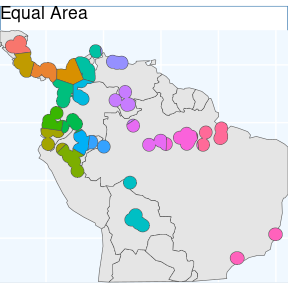

```r
eas <- EqualAreaSample(x_buff, planar_proj = planar_proj)

eas.p <- map +
  geom_sf(data = eas[['Geometry']], aes(fill = factor(ID))) +
#  geom_sf_label(data = eas.sf, aes(label = ID), alpha = 0.4) +
  labs(title = 'Equal Area') +
  coord_sf(expand = F)
eas.p
```

The results look quite similar to `PointBasedSample`.

## OpportunisticSample

Users may be interested in how they can embed their existing collections into a sampling framework. The function `OpportunisticSample` makes a few minor modifications to the point-based sample and designs it around existing collections. It may not perform well if collections are close together, but, as the saying goes, “a bird in hand is worth two in the bush”. As we have observed, the previous sampling schemes have produced somewhat similar results, so we used the `PointBasedSample` as the framework for embedding in this function.

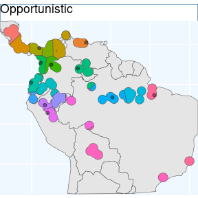

```r
exist_pts <- sf::st_sample(x_buff, size = 10) |>
   sf::st_as_sf() |> # ^^ randomly sampling 10 points in the species range
   dplyr::rename(geometry = x)

os <- OpportunisticSample(polygon = x_buff, n = 20, collections = exist_pts, reps = 50, BS.reps = 333)

os.p <- map +
  geom_sf(data = os[['Geometry']], aes(fill = factor(ID))) +
#  geom_sf_label(data = os.sf, aes(label = ID), alpha = 0.4) +
  geom_sf(data = exist_pts, alpha = 0.4) +
  labs(title = 'Opportunistic') +
  coord_sf(expand = F)

os.p
```

Here, the grids have been aligned around the existing collections. The results from this function can lead to some oddly shaped clusters, but *a bird in hand is worth two in the bush.*

## Isolation by Distance Based Sample

Note that this function requires a raster, rather than a vector, input.

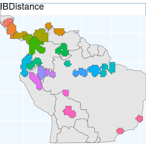

```r
files <- list.files(
  path = file.path(system.file(package="dismo"), 'ex'),
  pattern = 'grd',  full.names=TRUE )
predictors <- terra::rast(files)

x_buff.sf <- sf::st_as_sf(x_buff) |>
  dplyr::mutate(Range = 1) |>
  sf::st_transform( terra::crs(predictors))

# and here we specify the field/column with our variable we want to become an attribute of our raster
v <- terra::rasterize(x_buff.sf, predictors, field = 'Range')

# now we run the function demanding 20 areas to make accessions from,
ibdbs <- IBDBasedSample(
    x = v,
    n = 20,
    fixedClusters = TRUE,
    template = predictors,
    planar_proj = planar_proj
    )

ibdbs.p <- map +
  geom_sf(data = ibdbs[['Geometry']], aes(fill = factor(ID))) +
#  geom_sf_label(data = os.sf, aes(label = ID), alpha = 0.4) +
  labs(title = 'IBDistance') +
  coord_sf(expand = F)

## for the sake of comparing areas below, we will intersect this to the same extents as the earlier surfaces.
ibdbs_crop <- sf::st_intersection(ibdbs[['Geometry']], sf::st_union(x_buff.sf))
ibdbs.p2 <- map +
  geom_sf(data = ibdbs_crop, aes(fill = factor(ID))) +
#  geom_sf_label(data = os.sf, aes(label = ID), alpha = 0.4) +
  labs(title = 'IBDistance') +
  coord_sf(expand = F)

ibdbs.p
```

Because results are derived from rasters, clusters have straight lines and 90-degree corners. Despite the raster effects, cluster borders look more natural, and polygons align better with classes than previous methods.

## Isolation by Resistance

This workflow requires a couple of steps. We have a dedicated vignette for Isolation by Resistance with full details. Here, we will just load the data you get when you run that vignette.

```r
ibr <- sf::st_read(
  file.path(system.file(package="safeHavens"), 'extdata', 'IBR.gpkg'),
  quiet = TRUE)

ibr.p <- map +
  geom_sf(data = ibr, aes(fill = factor(ID))) +
  labs(title = 'IBResistance') +
  coord_sf(expand = F)
Coordinate system already present.
ℹ Adding new coordinate system, which will replace the existing one.
```

## PolygonBasedSample

This method is widely used for native seed collection in North America. However, I am not sure exactly how practitioners implement it, or whether the application formats are consistent among practitioners! For these reasons, a few different sets of options are supported for a user.

```r
neo_eco <- sf::st_read(
  file.path(system.file(package="safeHavens"), 'extdata', 'NeoTropicsEcoregions.gpkg'),
  quiet = TRUE) |>
  dplyr::rename(geometry = geom)

head(st_drop_geometry(neo_eco)[,c('Provincias', 'Dominio', 'Subregion')]) |>
  knitr::kable()
```

| Provincias | Dominio | Subregion |
| --- | --- | --- |
| Araucaria Forest province | Parana | Chacoan |
| Atacama province | NA | South American Transition Zone |
| Atlantic province | Parana | Chacoan |
| Bahama province | NA | Antillean |
| Balsas Basin province | Mesoamerican | Brazilian |
| Caatinga province | Chacoan | Chacoan |

```r
x_buff <- sf::st_transform(x_buff, sf::st_crs(neo_eco))
ebs.sf <- PolygonBasedSample(x_buff, zones = neo_eco, n = 20, zone_key = 'Provincias')

# crop it to the other objects for plotting
ebs.sf <- st_crop(ebs.sf, bb)

ebs.p <- map +
  geom_sf(data = ebs.sf , aes(fill = factor(allocation))) +
  labs(title = 'Ecoregion') +
  coord_sf(expand = F)
```

## EnvironmentalBasedSample

The `EnvironmentalBasedSample` can only be used if you have species distribution model data. We have included the outputs of the vignette ‘Species Distribution Model’ with the package so they are available to this vignette.

### load the SDM predictions

Here, we load the results of the sdm processing from the package data.

```r
sdModel <- readRDS(
  file.path(system.file(package="safeHavens"), 'extdata',  'sdModel.rds')
  )

sdModel$RasterPredictions <- terra::unwrap(sdModel$RasterPredictions)
sdModel$Predictors <- terra::unwrap(sdModel$Predictors)
sdModel$PCNM <- terra::unwrap(sdModel$PCNM)
```

And load the threshold predictions

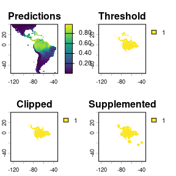

```r
sdm <- terra::rast(
  file.path(system.file(package="safeHavens"), 'extdata',  'SDM_thresholds.tif')
  )
terra::plot(sdm)
```

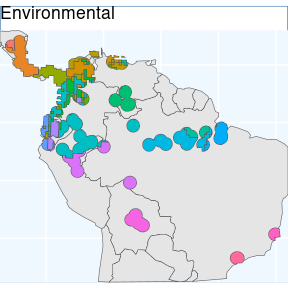

```r
rr <- RescaleRasters( # you may have already done this!
  model = sdModel$Model,
  predictors = sdModel$Predictors,
  training_data = sdModel$TrainData,
  pred_mat = sdModel$PredictMatrix
  )

# create a directory to hold the results from EBS real quick.
# we will default to placing it in your current working directory.
getwd() # this is where the folder is going to be created if you do not run the code below.
[1] "/home/sagesteppe/Documents/assoRted/safeHavens/vignettes"
p <- file.path(path.expand('~'), 'Documents') # in my case I'll dump it in Documents real quick, this should work on

# optional, intentionally create a directory to hold results
# dir.create(file.path(p, 'safeHavens-Vignette'))

planar_proj <- "+proj=laea +lat_0=-15 +lon_0=-60 +x_0=0 +y_0=0 +datum=WGS84 +units=m +no_defs"

ENVIbs <- EnvironmentalBasedSample(
  pred_rescale = rr$RescaledPredictors,
  write2disk = FALSE, # we are not writing, but showing how to provide some arguments
  path = file.path(p, 'safeHavens-Vignette'),
  taxon = 'Bradypus_test',
  f_rasts = sdm,
  coord_wt = 2,
  n = 20,
  lyr = 'Supplemented',
  fixedClusters = TRUE,
  n_pts = 500,
  planar_proj = planar_proj,
  buffer_d = 3,
  prop_split = 0.8
  )

## for the sake of comparing areas below, we will intersect this to the same extents as the earlier surfaces.
ENVIbs_crop <- sf::st_intersection(ENVIbs[['Geometry']], sf::st_union(x_buff.sf))
Warning: attribute variables are assumed to be spatially constant throughout
all geometries

ENVIbs.p <- map +
  geom_sf(data = ENVIbs_crop, aes(fill = factor(ID))) +
  #geom_sf_label(data = ENVIbs, aes(label = ID), alpha = 0.4) +
  labs(title = 'Environmental') +
  coord_sf(expand = FALSE)
Coordinate system already present.
ℹ Adding new coordinate system, which will replace the existing one.

ENVIbs.p
```

The function `EnvironmentalBasedSample` can take any of the three binary rasters created by `PostProcessSDM` as arguments for the template. Here we showcase the different results from using each of them.

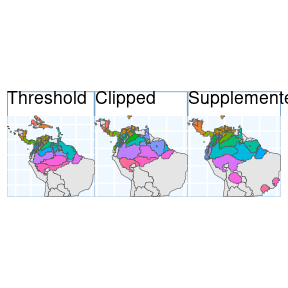

Using the threshold raster surface is a very good option if we do not want to ‘miss’ too many areas, whereas the clipped and supplemented options may be better suited for scenarios where we do not want to draw up clusters that lack any populations that can be collected from.

# Comparision of different sampling schemes

So, we have some maps for you to look at! They all *looked* relatively similar to me when plotted one after another. Let’s plot them together and see if that’s still the case.

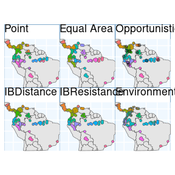

```r
pbs.p + eas.p + os.p  +  ibdbs.p2 + ibr.p + ENVIbs.p +
  plot_layout(ncol = 3)
```

The application of `PolygonBasedSample` to the data is difficult to evaluate in the same way as the other data sets, but it did identify the desired sampling regions. We do not show it in this pane. Isolation by Resistance is similar to IBD; however, it makes fewer splits in Central America and instead picks them up in Peru.

Relative to IBR, Isolation by Environment tends to split locations across the Andes and the NW coastal regions of South America. The ranges are relatively contiguous enough to sensibly sample from. Contiguity of ranges in this approach can be controlled with the coord_wt argument.